# Test a Perceptual Phenomenon

```python
# works for python 3.0
from IPython.core.display import HTML
import urllib.request
request = urllib.request.Request('http://bit.ly/1Bf5Hft')
response = urllib.request.urlopen(request)
HTML(response.read().decode('utf-8'))
```

[project link](https://docs.google.com/document/d/1-OkpZLjG_kX9J6LIQ5IltsqMzVWjh36QpnP2RYpVdPU/pub?embedded=True)

https://review.udacity.com/#!/rubrics/71/view

https://en.wikipedia.org/wiki/Stroop_effect

# Background Information

In a Stroop task, participants are presented with a list of words, with each word displayed in a color of ink. The participant’s task is to say out loud the color of the ink in which the word is printed. The task has two conditions: a congruent words condition, and an incongruent words condition. In the congruent words condition, the words being displayed are color words whose names match the colors in which they are printed: for example RED, BLUE. In the incongruent words condition, the words displayed are color words whose names do not match the colors in which they are printed: for example PURPLE, ORANGE. In each case, we measure the time it takes to name the ink colors in equally-sized lists. Each participant will go through and record a time from each condition.

# Questions For Investigation

As a general note, be sure to keep a record of any resources that you use or refer to in the creation of your project. You will need to report your sources as part of the project submission.

1. What is our independent variable? What is our dependent variable?

**Ans:** independent variable is the two different conditions, whether it is congruent or incongruent.

dependent variable is the reading time.

\2. What is an appropriate set of hypotheses for this task? What kind of statistical test do you expect to perform? Justify your choices.

Ans:

- Null hypothesis: the congruent group and the incongruent group has the same mean value, with a significant value of 5%. $H_0: \mu_1=\mu_2$. Here $\mu$ is the mean value for each group.
- Alternative hypothesis:The mean of the incongruent group is outside the critical region of the mean of congruent group. $H_a: \mu_1 \neq \mu_2$

The kind of statistical test is **dependent sample t-test** on 2 conditions. Because we have relative few samples (<30), we don't know the mean and standard deviation of the population, and we assume the distribution are Gaussian

\3. Report some descriptive statistics regarding [this dataset](https://www.google.com/url?q=https://drive.google.com/file/d/0B9Yf01UaIbUgQXpYb2NhZ29yX1U/view?usp%3Dsharing&sa=D&ust=1487887532881000&usg=AFQjCNF6W3Dm_zTuLyhH2jZJBFsMnET7ng) . Include at least one measure of central tendency and at least one measure of variability.

**Ans:** As shown below, the congruent group has a mean of 14.05 and std of 3.56, the incongruent group has a mean of 22.02 and std of 4.80

```python
import pandas as pd
import numpy as np
from matplotlib import pyplot as plt
import seaborn as sns
% matplotlib inline

data = pd.read_csv('stroopdata.csv')
```

```python
data.info()
```

```
<class 'pandas.core.frame.DataFrame'>
RangeIndex: 24 entries, 0 to 23
Data columns (total 2 columns):
Congruent      24 non-null float64
Incongruent    24 non-null float64
dtypes: float64(2)
memory usage: 464.0 bytes
```

```python
data.describe()
```

|  | Congruent | Incongruent |
| --- | --- | --- |
| count | 24.000000 | 24.000000 |
| mean | 14.051125 | 22.015917 |
| std | 3.559358 | 4.797057 |
| min | 8.630000 | 15.687000 |
| 25% | 11.895250 | 18.716750 |
| 50% | 14.356500 | 21.017500 |
| 75% | 16.200750 | 24.051500 |
| max | 22.328000 | 35.255000 |

\4. Provide one or two visualizations that show the distribution of the sample data. Write one or two sentences noting what you observe about the plot or plots. **Ans:** As shown below, the incongruent group has signficantly longer time.

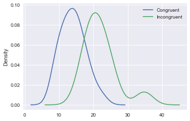

```python
data.plot(kind='kde')
```

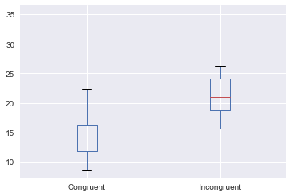

```python
data.boxplot()
```

\5. Now, perform the statistical test and report your results. What is your confidence level and your critical statistic value? Do you reject the null hypothesis or fail to reject it? Come to a conclusion in terms of the experiment task. Did the results match up with your expectations?

**Ans:** This is a dependent sample test. From t-table, for 95% confident level with 23 degree of freedom, the t critical value is 2.069. So t=8.02 means the incongruent task take much more time than the congruent task. It is **statistically significant**. So we reject the null hypothesis, which is what I expect.

```python
s1 = data['Congruent']
s2 = data['Incongruent']
mean_diff = s2.mean()-s1.mean()
length = len(s1)
sample_sd = np.sqrt(np.var(s2-s1)*length/(length-1))
t = mean_diff/sample_sd*np.sqrt(length)
print('mean_diff={0:.2f}\n sample_sd={1:.3f}\n t={2:.3f}'.format(mean_diff,sample_sd,t))
```

```
mean_diff=7.96
 sample_sd=4.865
 t=8.021
```

\6. Optional: What do you think is responsible for the effects observed? Can you think of an alternative or similar task that would result in a similar effect? Some research about the problem will be helpful for thinking about these two questions!

**ans:** The effect is due to the inconsistency between the name tag and the actual property of a given object. In psychology, there is a theory called cognitive dissonance, which desribes the conflicts between 2 cognitive systems. The Stroop effect is real life is actually **more hidden and subtle**, and can be used to affect customer's behavior. Like the background laughing in a comedian show, the exaggerated ad of a big brand product (i.e., Coke, or Pizza)